# Least Squares Regression

### Example: Statistics Midterm Grades

Not surprisingly, there is a strong correlation between a student’s grades on different midterm exams. Here is data from my sections of statistics from 2013-2015.

```r
exams <- read.csv('http://people.hsc.edu/faculty-staff/blins/StatsExamples/midtermRegressionS13_F15.csv')
# First six rows
head(exams)
```

```
##   Midterm1 Midterm2
## 1       52       54
## 2       70       73
## 3       86       89
## 4       73       62
## 5       92       85
## 6       47       72
```

```r
# Number of rows and columns
dim(exams)
```

```
## [1] 180   2
```

```r
# Midterm averages
apply(exams, MARGIN = 2, FUN = mean) # Applies the function mean() to the columns. MARGIN = 1 would apply the function to the rows instead.
```

```
## Midterm1 Midterm2
## 76.77778 74.16667
```

```r
# Standard deviations
apply(exams, MARGIN = 2, FUN = sd)
```

```
## Midterm1 Midterm2
## 14.51855 13.81017
```

### Scatterplots

It is very easy to make scatterplots in R.

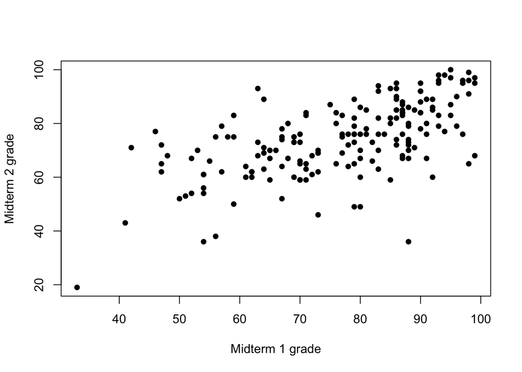

```r
plot(exams$Midterm1, exams$Midterm2, xlab = "Midterm 1 grade", ylab = "Midterm 2 grade", pch = 16)
```

### Correlation

The `cor()` function calculates the correlation between two different vectors of data.

```r
cor(exams$Midterm1, exams$Midterm2)
```

```
## [1] 0.6094617
```

### Linear Regression

The command `lm()` will construct a least squares linear regression model for predicting one variable based on another. Here `lm` stands for **linear model**. The syntax is a little different than other commands. Here is an example of how to use it.

```r
myLM <- lm(Midterm2 ~ Midterm1, data = exams)
myLM
```

```
##
## Call:
## lm(formula = Midterm2 ~ Midterm1, data = exams)
##
## Coefficients:
## (Intercept)     Midterm1
##     29.6567       0.5797
```

Notice that the linear model contains the slope and the y-intercept for the least squares regression line. The slope is the coefficient on the Midterm1 grade, so it is the number 0.5797. This means: *for every 1 point higher a student gets on midterm 1, their midterm 2 grade tends to be 0.5797 points higher, on average.*

### Plotting Trendlines

You can add the trendline to the scatterplot with the command `abline()`.

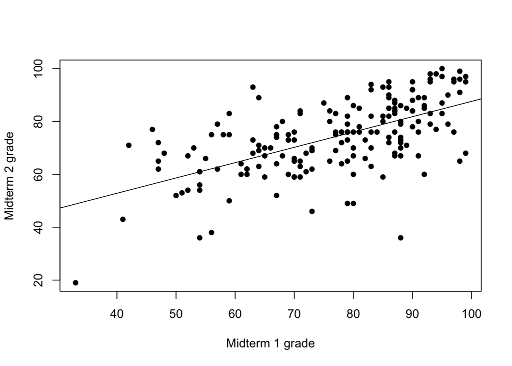

```r
plot(exams$Midterm1, exams$Midterm2, xlab="Midterm 1 grade", ylab="Midterm 2 grade", pch = 16)
abline(myLM) # Adds the trendline to the scatterplot
```

### Making Predictions

If you want to predict a y-value based on a particular x-value, use the `predict()` function. The arguments of `predict()` are a linear model and a data frame with a header that has the same name as the x-variable in the linear model. In this example, the second argument is a simple data frame with two values for Midterm 1, one student who gets a 50 and another student who gets a 100.

```r
predict(myLM, data.frame(Midterm1 = c(50,100)))
```

```
##        1        2
## 58.64292 87.62917
```

Based on the results, it looks like students who get a 50 on midterm 1 will have an average grade of about 58.6 on midterm 2. On the other hand, students with a perfect score on midterm 1 will only have an average grade of 87.6 on midterm 2. This phenomenon is known as **regression to the mean**: *the predicted outcomes in a linear regression model tend to be less extreme than then inputs.*

### Checking Inference Conditions with Residual Plots

The function `resid()` takes a linear model (like `myLM`) and returns the residuals. You can use this to plot the residuals against the x-values which is often useful if you want to assess whether data really follows a linear model and whether the conditions for statistical inference are met.

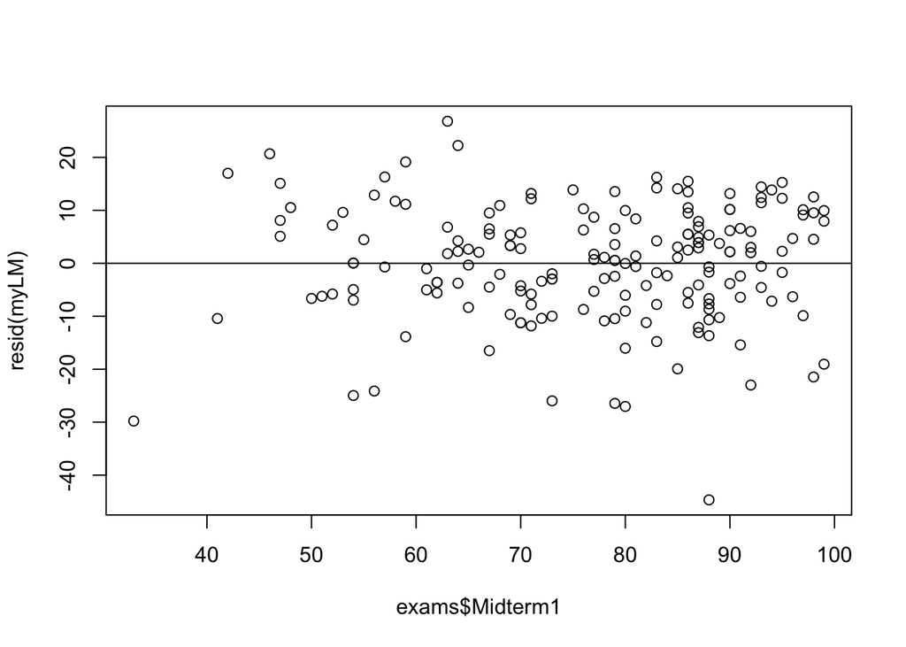

```r
plot(exams$Midterm1, resid(myLM))
abline(0,0) # Add line with slope = 0 and y-intercept = 0 to the residual plot
```

It looks like the residuals have a similar variance throughout. But if you look at a qqplot, you can see that the residuals are not normally distributed.

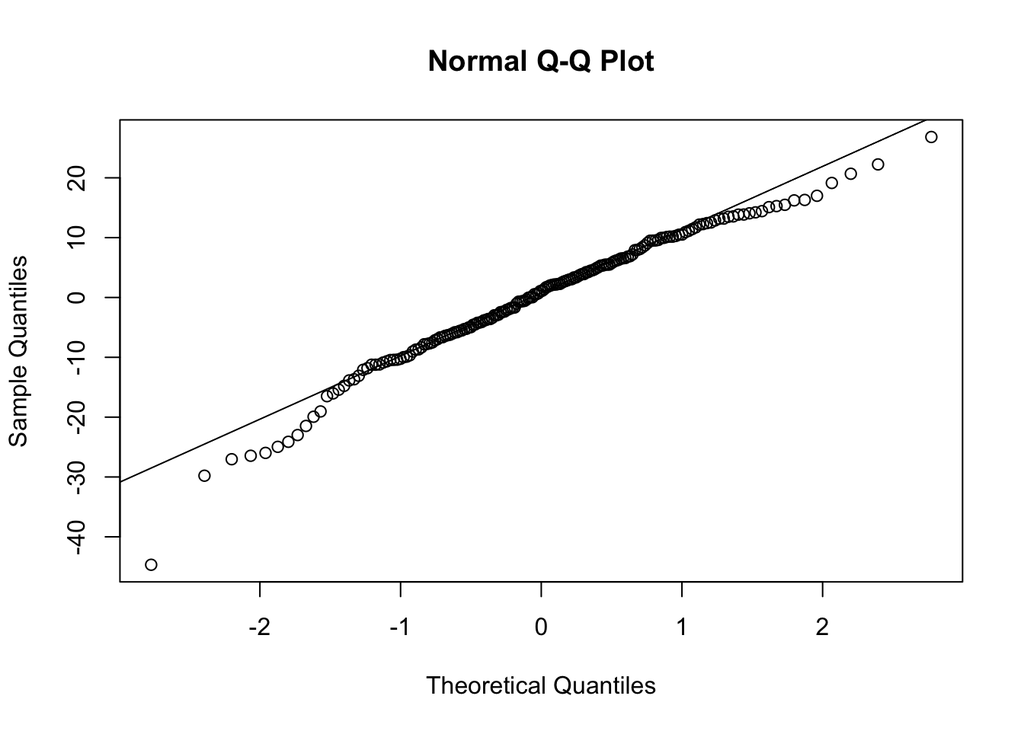

```r
qqnorm(resid(myLM))
qqline(resid(myLM))
```

That’s probably not a big issue since the sample size is large ($n = 180$).

### Other Information

A linear model in R contains a lot of useful information that can be accessed using the `summary()` function. This information will be particularly useful when we apply statistical inference techniques to linear regression.

```r
summary(myLM)
```

```
##
## Call:
## lm(formula = Midterm2 ~ Midterm1, data = exams)
##
## Residuals:
##     Min      1Q  Median      3Q     Max
## -44.672  -6.336   1.096   7.918  26.821
##
## Coefficients:
##             Estimate Std. Error t value Pr(>|t|)
## (Intercept) 29.65667    4.41632   6.715 2.43e-10 ***
## Midterm1     0.57972    0.05652  10.256  < 2e-16 ***
## ---
## Signif. codes:  0 '***' 0.001 '**' 0.01 '*' 0.05 '.' 0.1 ' ' 1
##
## Residual standard error: 10.98 on 178 degrees of freedom
## Multiple R-squared:  0.3714, Adjusted R-squared:  0.3679
## F-statistic: 105.2 on 1 and 178 DF,  p-value: < 2.2e-16
```

You can get an ANOVA table for a linear model using the `anova()` function.

```r
anova(myLM)
```

```
## Analysis of Variance Table
##
## Response: Midterm2
##            Df Sum Sq Mean Sq F value    Pr(>F)
## Midterm1    1  12681 12680.7  105.19 < 2.2e-16 ***
## Residuals 178  21458   120.6
## ---
## Signif. codes:  0 '***' 0.001 '**' 0.01 '*' 0.05 '.' 0.1 ' ' 1
```